# IE 425 Homework 2

Yusuf Sina Öztürk

Last edited June 09, 2021

### Introduction

We are going to use most of the time `caret` package. In the first question, we are going to use `RandomForest` algorithm with `k-fold Cross-Validation` approach. In the second question, we are going to use `Gradient Boosting Machines` algorithm to built our model and our decision measure is going to be `RMSE` during the whole report.

Lets get started!

### Partition Data Set to Training and Test Sets (Q1.a)

First of all, In the data, there is input variables which need to be changed to factor type.

```r
ToyotaCorolla = read.csv("ToyotaCorolla.csv")

ToyotaCorolla$FuelType = as.factor(ToyotaCorolla$FuelType)
ToyotaCorolla$MetColor = as.factor(ToyotaCorolla$MetColor)
ToyotaCorolla$Automatic = as.factor(ToyotaCorolla$Automatic)
```

Then using seed value of 425, partition the data to training and test set with ratio 0.7.

Training set is called `Corollatr` and test set is called `Corollate`

```r
set.seed(425)
rndSample = sample(1:nrow(ToyotaCorolla), nrow(ToyotaCorolla)*0.7)
Corollatr = ToyotaCorolla[rndSample,]
Corollate = ToyotaCorolla[-rndSample,]
```

Now we have training set which has 1005 observations and test set with 431 observations.

### Choosing Model with RandomForest Algorithm with k-fold CV Aproach (Q1.b)

First of all we need to set `trControl` argument of the `train()` function.

As in the question told us that we need to use `repeatedcv` with 5 repeats to 10-fold CV.

```r
set.seed(425)
ctrl1 = trainControl(method = 'repeatedcv', number = 10, repeats = 5)
```

Now, we can use this `ctrl1` into our models easily.

Because we are going to change `mtry` and `ntree` values of the `RandomForest`, we can use `train()` function. However, the function does not let us change `ntree` values automatically. Thus, we are going to build models for each `ntree` value manually.

Lets start with `ntree = 100`

```r
set.seed(425)
fit1 = train(Price~., data = Corollatr, method = "rf", metric = "RMSE", trControl = ctrl1,ntree = 100, tuneGrid = expand.grid(.mtry = (1:10)))
fit1
```

```
## Random Forest
##
## 1005 samples
##    9 predictor
##
## No pre-processing
## Resampling: Cross-Validated (10 fold, repeated 5 times)
## Summary of sample sizes: 904, 905, 905, 904, 905, 905, ...
## Resampling results across tuning parameters:
##
##   mtry  RMSE      Rsquared   MAE
##    1    1886.729  0.8544022  1412.1365
##    2    1206.472  0.9029063   885.9897
##    3    1116.292  0.9119401   827.5922
##    4    1094.048  0.9144254   821.8116
##    5    1097.745  0.9135679   823.2763
##    6    1095.177  0.9137451   823.2313
##    7    1101.780  0.9127419   828.0210
##    8    1112.497  0.9111314   833.6439
##    9    1119.725  0.9098027   836.4219
##   10    1127.838  0.9084695   840.0481
##
## RMSE was used to select the optimal model using the smallest value.
## The final value used for the model was mtry = 4.
```

As we can see the output, function selected `mtry = 4` and it’s `RMSE = 1094.048`

Now, lets try `ntree = 200` and check whether our RMSE measure improved or not.

```r
set.seed(425)
fit2 = train(Price~., data = Corollatr, method = "rf", metric = "RMSE", trControl = ctrl1,ntree = 200, tuneGrid = expand.grid(.mtry = (1:10)))
fit2
```

```
## Random Forest
##
## 1005 samples
##    9 predictor
##
## No pre-processing
## Resampling: Cross-Validated (10 fold, repeated 5 times)
## Summary of sample sizes: 904, 905, 905, 904, 905, 905, ...
## Resampling results across tuning parameters:
##
##   mtry  RMSE      Rsquared   MAE
##    1    1884.407  0.8558267  1410.0528
##    2    1203.804  0.9036382   885.3963
##    3    1112.072  0.9127386   825.5638
##    4    1092.818  0.9146254   820.4661
##    5    1092.447  0.9144238   821.3015
##    6    1092.927  0.9141972   821.7052
##    7    1099.729  0.9130375   826.5326
##    8    1108.258  0.9117919   830.0341
##    9    1117.890  0.9101238   834.1331
##   10    1126.776  0.9087376   838.9337
##
## RMSE was used to select the optimal model using the smallest value.
## The final value used for the model was mtry = 5.
```

Here as we can see, `mtry = 5` and it’s `RMSE = 1092.447`.

We have slight improvement in RMSE values here compared to `fit1`.

Also we can see that 4th,5th and 6th mtry values are close to each other but function selection is depend on RMSE values.

Now, lets increase the `ntree` parameter to 300.

```r
set.seed(425)
fit3 = train(Price~., data = Corollatr, method = "rf", metric = "RMSE", trControl = ctrl1,ntree = 300, tuneGrid = expand.grid(.mtry = (1:10)))
fit3
```

```
## Random Forest
##
## 1005 samples
##    9 predictor
##
## No pre-processing
## Resampling: Cross-Validated (10 fold, repeated 5 times)
## Summary of sample sizes: 904, 905, 905, 904, 905, 905, ...
## Resampling results across tuning parameters:
##
##   mtry  RMSE      Rsquared   MAE
##    1    1881.202  0.8567207  1409.0412
##    2    1203.207  0.9037710   886.0122
##    3    1109.762  0.9130187   824.7461
##    4    1092.041  0.9147681   819.0708
##    5    1088.795  0.9150280   818.6430
##    6    1092.716  0.9142613   820.4218
##    7    1100.538  0.9129193   826.5668
##    8    1107.731  0.9118121   829.9442
##    9    1116.815  0.9103299   833.1447
##   10    1127.092  0.9086936   838.9684
##
## RMSE was used to select the optimal model using the smallest value.
## The final value used for the model was mtry = 5.
```

Here, `mtry = 5` and `RMSE = 1088.795`. It is looks like that when we increase the `ntree` value, we have better and better RMSE values.

Lets increase our `ntree` parameter to 400

```r
set.seed(425)
fit4 = train(Price~., data = Corollatr, method = "rf", metric = "RMSE", trControl = ctrl1,ntree = 400, tuneGrid = expand.grid(.mtry = (1:10)))
fit4
```

```
## Random Forest
##
## 1005 samples
##    9 predictor
##
## No pre-processing
## Resampling: Cross-Validated (10 fold, repeated 5 times)
## Summary of sample sizes: 904, 905, 905, 904, 905, 905, ...
## Resampling results across tuning parameters:
##
##   mtry  RMSE      Rsquared   MAE
##    1    1880.103  0.8566517  1407.8015
##    2    1200.833  0.9041334   885.2126
##    3    1108.827  0.9132392   823.8048
##    4    1092.098  0.9147725   818.7855
##    5    1088.504  0.9149991   818.5069
##    6    1093.242  0.9142196   820.5034
##    7    1100.201  0.9129260   825.8419
##    8    1107.050  0.9118931   828.8958
##    9    1116.152  0.9104276   832.7788
##   10    1126.465  0.9087777   838.7298
##
## RMSE was used to select the optimal model using the smallest value.
## The final value used for the model was mtry = 5.
```

When we set `ntree = 400`, we have also slightly better RMSE values which is `RMSE = 1088.504` and `mtry = 5`.

Finally, we can increase `ntree` to 500 and after that we can select our best model for this part.

```r
set.seed(425)
fit5 = train(Price~., data = Corollatr, method = "rf", metric = "RMSE", trControl = ctrl1,ntree = 500, tuneGrid = expand.grid(.mtry = (1:10)))
fit5
```

```
## Random Forest
##
## 1005 samples
##    9 predictor
##
## No pre-processing
## Resampling: Cross-Validated (10 fold, repeated 5 times)
## Summary of sample sizes: 904, 905, 905, 904, 905, 905, ...
## Resampling results across tuning parameters:
##
##   mtry  RMSE      Rsquared   MAE
##    1    1880.155  0.8569283  1407.5008
##    2    1200.317  0.9042235   885.1488
##    3    1108.663  0.9132887   823.4255
##    4    1091.929  0.9147600   818.6000
##    5    1088.604  0.9149797   818.3789
##    6    1093.659  0.9141360   820.8828
##    7    1099.642  0.9130258   825.2280
##    8    1106.439  0.9120010   828.2187
##    9    1115.840  0.9104610   832.7461
##   10    1126.245  0.9088247   838.5728
##
## RMSE was used to select the optimal model using the smallest value.
## The final value used for the model was mtry = 5.
```

Here in this `fit5` model, we have the RMSE value which is `RMSE = 1088.604` and we have `mtry = 5`.

However, in our `fit4` which has `ntree = 400` has slightly better RMSE value. Therefore, we should use `fit4` to do our predictions.

We can also see in the below plot that, at `mtry = 5` the `fit4` model has the smallest RMSE value.

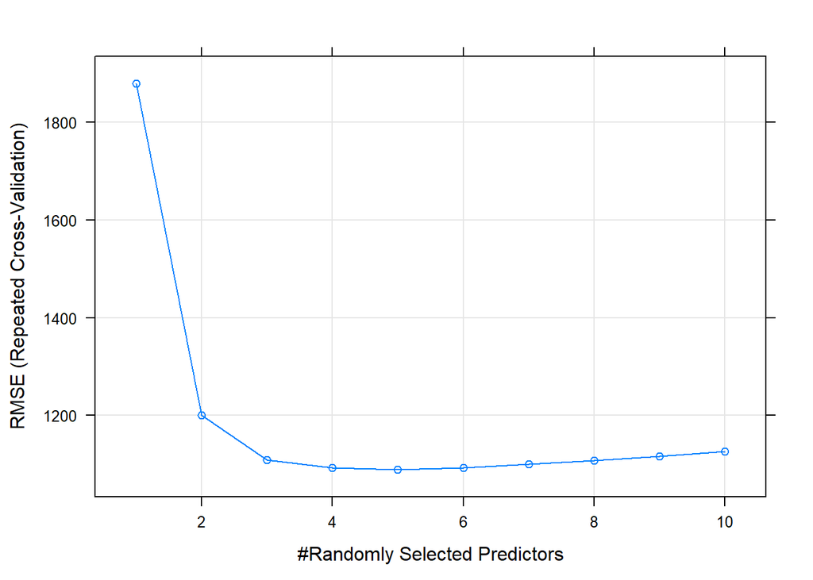

```r
plot(fit4, metric = "RMSE")
```

Now, we can use this `fit4` model to do our prediction.

With using our test set which we already set to `Corollate`, we can do prediction.

```r
fit4pred = predict(fit4, newdata = Corollate )
RMSE(fit4pred, Corollate$Price)
```

```
## [1] 1076.16
```

Prediction RMSE value is almost at the same level as actual `fit4` RMSE value. Therefore, we cannot say that our model is overfitted or underfitted.

### Important Input Attributes (Q1.c)

We decided to use `fit4` model to do our predictions. This model has the parameters that `ntree = 400` and `mtry = 5`.

`mtry` parameter shows us that how many input variables are used to build the model.

Lets see which of the input variables are used in our `fit4` model!

```r
varImp(fit4)
```

```
## rf variable importance
##
##                 Overall
## Age            100.0000
## KM              28.9795
## Weight          17.6343
## HP               4.9668
## CC               2.2670
## Doors            0.6783
## FuelTypePetrol   0.5187
## MetColor1        0.4275
## FuelTypeDiesel   0.2829
## Automatic1       0.0000
```

As we can see from the table, the variables with highest importance values are Age, KM,Weight, HP and CC variables sequentially.

### Comparison with Linear Regression (Q1.d)

Now, we need to build a linear regression model to compare these two models.

Also with `train()` function we can built linear regression models as I did below.

```r
set.seed(425)
lmfit = train(Price~., data = Corollatr, method = "lm",  metric = "RMSE", trControl = ctrl1)
summary(lmfit)
```

```
##
## Call:
## lm(formula = .outcome ~ ., data = dat)
##
## Residuals:
##      Min       1Q   Median       3Q      Max
## -11245.1   -728.7     -8.2    693.7   6234.0
##
## Coefficients:
##                  Estimate Std. Error t value Pr(>|t|)
## (Intercept)    -9.428e+03  1.659e+03  -5.682 1.75e-08 ***
## Age            -1.180e+02  3.023e+00 -39.040  < 2e-16 ***
## KM             -1.673e-02  1.572e-03 -10.643  < 2e-16 ***
## FuelTypeDiesel  2.743e+03  5.930e+02   4.626 4.22e-06 ***
## FuelTypePetrol  1.362e+03  3.726e+02   3.656 0.000269 ***
## HP              4.909e+01  6.635e+00   7.399 2.91e-13 ***
## MetColor1       3.421e+01  8.776e+01   0.390 0.696809
## Automatic1      7.128e+01  1.783e+02   0.400 0.689448
## CC             -4.011e+00  6.271e-01  -6.395 2.46e-10 ***
## Doors          -3.085e+01  4.738e+01  -0.651 0.515124
## Weight          2.596e+01  1.553e+00  16.719  < 2e-16 ***
## ---
## Signif. codes:  0 '***' 0.001 '**' 0.01 '*' 0.05 '.' 0.1 ' ' 1
##
## Residual standard error: 1284 on 994 degrees of freedom
## Multiple R-squared:  0.883,  Adjusted R-squared:  0.8818
## F-statistic:   750 on 10 and 994 DF,  p-value: < 2.2e-16
```

We built our linear regression models with using all the variables. As you can see from the summary, here more input variables have importance compared to our `fit4` model.

```r
lmfit$results$RMSE
```

```
## [1] 1321.047
```

Here RMSE value of linear regression model is significantly worse than `fit4` which is built by using RandomForest algorithm.

Also we can compare predicted RMSE values here;

```r
lmfitpred = predict(lmfit, newdata = Corollate)
RMSE(lmfitpred, Corollate$Price)
```

```
## [1] 1426.332
```

Here, Predicted RMSE value of linear regression model is 1426.332. On the other hand, predicted RMSE value of RandomForest model has 1076.16. There is significant difference between these two models.

With regard to only RMSE values, we can select `fit4` model.

### Gradient Boosting Machines (Q2)

In this section, we are going to build a model with using same data set with using Gradient Boosting Machine algorithm.

First of all, we need to have a grid from the given parameters values in the question.

```r
gbmGrid = expand.grid(n.trees = 50 + (1:4)*25,
                      interaction.depth = 2 + (1:3)*1,
                      n.minobsinnode = (1:3)*5,
                      shrinkage = (1:3)*0.1)
nrow(gbmGrid)
```

```
## [1] 108
```

Now, we can build our model with using this grid again with `train()` function.

```r
set.seed(425)
gbmfit = train(Price~., data = Corollatr, method = "gbm", metric = "RMSE", verbose = FALSE, trControl = ctrl1, tuneGrid = gbmGrid)
gbmfit$bestTune
```

```
##    n.trees interaction.depth shrinkage n.minobsinnode
## 16     150                 4       0.1              5
```

With using those parameters, Gradient Boosting Machine algorithm found the best RMSE value. Lets try to print that RMSE value.

```r
gbmfit$results$RMSE[which.min(gbmfit$results$RMSE)]
```

```
## [1] 1103.37
```

This RMSE value is worse than the RandomForest model RMSE (fit4).

Lets also check predicted RMSE value!

```r
gbmfitpred = predict(gbmfit, newdata = Corollate)
RMSE(gbmfitpred,Corollate$Price)
```

```
## [1] 1068.171
```

This RMSE value actually, the best predicted RMSE value compared to other linear regression and RandomForest models. We need to be further investigate whether this results is coincidence or not.

#### Conclusion

We try to find the best parameters for RandomForest and Gradient Boosting Machine algorithms with using caret package functions.

We also had a small interpretation about the importance of the input variables in the data.

After that, we compare our best models with each other and linear regression model.